# 통계밥법론 Chap5_후반부 실습코드

202140191 엄태훈

2021-04-03(SAT)

# Chap5 Introductory Inference

174P~195P Chap5의 남은 절반 부분에 대해서 실습을 진행했습니다.

## 5.6.2 Sample Size for Hypothesis Testing

가설검정을 진행하는 경우 우리는 Type 2 Error에 대해서 제어하는 것에 관심이있다.  
분산이 알려져 있을 때 단측검정을 위해 적절한 표본의 수에 대해서 계산하는 방법이다.

```r
## one sided
# install.packages("HH")
library("HH")
alpha <- 0.05

power <- 0.80

beta <- 1 - power

delta <- 1

sd <- 2

## Approximation using formula assuming normal is appropriate
sd^2*(qnorm(1-alpha) + qnorm(1-beta))^2 / delta^2
```

```
## [1] 24.73023
```

```r
## n is slightly smaller with the normal assumption.
```

R에 내장돼있는 power.t.test 함수를 통해 one-sample-t, two-sample-t에 대해서 적절한 표본 수를 계산할 수 있다.

```r
## solve using power.t.test
PTT <- power.t.test(delta=delta, sd=sd, sig.level=alpha, power=power, type="one.sample", alternative = "one.sided")
PTT
```

```
##
##      One-sample t test power calculation
##
##               n = 26.13751
##           delta = 1
##              sd = 2
##       sig.level = 0.05
##           power = 0.8
##     alternative = one.sided
```

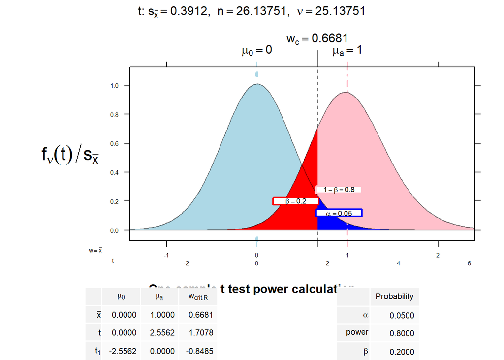

```r
NTplot(PTT, zaxis=TRUE)
```

```r
#NTplot (PTT, zaxis=TRUE, shiny=TRUE)
```

power.t.test 함수를 이용하지 않고 단측 표본 t검정의 크기를 수동적으로 계산할 수 있다.

```r
## solve manually with t distribution.
## Use ncp for alternative.

n0 <- 30 ## pick an n0 for starting value
# 주어진 유의수준과 자유도를 이융하여 t의 임계값을 구한다.
t.critical <- qt(1-alpha,df=n0-1)
t.critical
```

```
## [1] 1.699127
```

```r
nn <- 23:30
names(nn) <- nn
nn
```

```
## 23 24 25 26 27 28 29 30
## 23 24 25 26 27 28 29 30
```

```r
## find the power for a series of n values for the specified critical value
pt(t.critical,df=nn-1,ncp=delta/(sd/sqrt(nn)),lower=FALSE)
```

```
##        23        24        25        26        27        28        29        30
## 0.7567776 0.7721918 0.7867744 0.8005544 0.8135615 0.8258266 0.8373804 0.8482542
```

```r
## recalculate critical values with new n = 26
t.critical <- qt(1-alpha,df=26-1)
t.critical
```

```
## [1] 1.708141
```

```r
## find the power for a series of n values for the new critical value
pt(t.critical,df=nn-1,ncp=delta/(sd/sqrt(nn)),lower=FALSE)
```

```
##        23        24        25        26        27        28        29        30
## 0.7539976 0.7695028 0.7841789 0.7980537 0.8111566 0.8235176 0.8351671 0.8461357
```

```r
## conclude a between 26 and 27

PTT2 <- power.t.test(delta=1, sd=2, sig.level=0.05, power=0.85, type="one.sample", alternative = "one.sided")
PTT2
```

```
##
##      One-sample t test power calculation
##
##               n = 30.1596
##           delta = 1
##              sd = 2
##       sig.level = 0.05
##           power = 0.85
##     alternative = one.sided
```

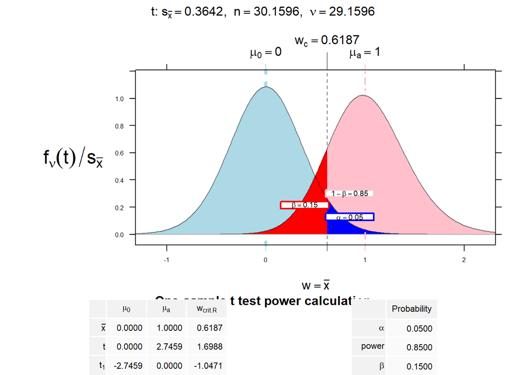

```r
NTplot(PTT2)
```